# Predice Housing Prices using Bagging and Random Forests

## Analysis

### Run Bagging

The randomForest() function will perform for both forests and bagging.

Bagging is just a special case of a random forest with $m=p$

```r
library(MASS) # For the Boston dataset
library(randomForest)
set.seed(1)
train = sample(1:nrow(Boston), nrow(Boston)/2) # 50% of random data
bag.boston <- randomForest(medv~., data=Boston, subset=train, mtry=13, importance=TRUE)
bag.boston
```

```
##
## Call:
##  randomForest(formula = medv ~ ., data = Boston, mtry = 13, importance = TRUE,      subset = train)
##                Type of random forest: regression
##                      Number of trees: 500
## No. of variables tried at each split: 13
##
##           Mean of squared residuals: 11.08966
##                     % Var explained: 86.57
```

`mtry=13` indicates that all 13 predictors should be considered for each split of the tree.

### Predict Bagging model

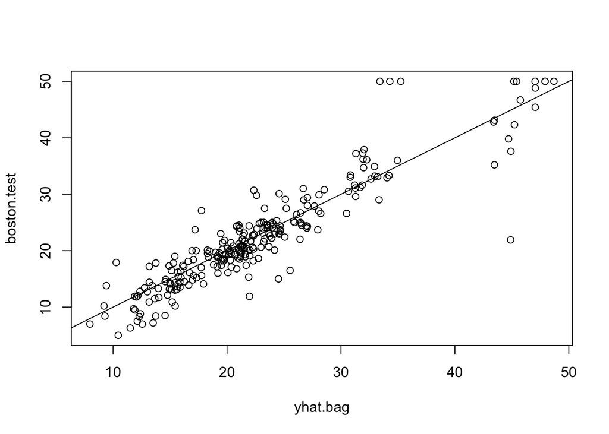

```r
boston.test <- Boston[-train,"medv"] # The response
yhat.bag <- predict(bag.boston, newdata=Boston[-train,]) # Predict using any of the
plot(yhat.bag, boston.test)
abline(0,1)
```

```r
mean((yhat.bag-boston.test)^2) # MSE Error
```

```
## [1] 13.33831
```

We see in the plot how far away the testing respones compare with the straight line.

### Run and predict Random Forest with a specific number of trees

We could change the number of trees grown using the `ntree` argument.

```r
bag.boston <- randomForest(medv~., data=Boston, subset=train, mtry=13, ntree=25) # we choose 25 tree
yhat.bag <- predict(bag.boston, newdata=Boston[-train,])
mean((yhat.bag-boston.test)^2) # Check MSE Error
```

```
## [1] 15.96786
```

### Run and predict Random Forest with smaller value of `mtry`

By default, random Forest uses $\frac{1}{p}$ variables than random forest of regression trees and use $\sqrt{p}$ and we use `mtry=6` this time.

We are leaving number of trees of default.

```r
set.seed(1)
rf.boston <- randomForest(medv~., data=Boston, subset=train, mtry=6, importance=TRUE)
yhat.rf <- predict(rf.boston, newdata=Boston[-train,])
mean((yhat.rf-boston.test)^2)
```

```
## [1] 11.48022
```

### To view the importane of each variable

We wil use `importance()` to see the importance of variables.

```r
importance(rf.boston)
```

```
##           %IncMSE IncNodePurity
## crim    12.547772    1094.65382
## zn       1.375489      64.40060
## indus    9.304258    1086.09103
## chas     2.518766      76.36804
## nox     12.835614    1008.73703
## rm      31.646147    6705.02638
## age      9.970243     575.13702
## dis     12.774430    1351.01978
## rad      3.911852      93.78200
## tax      7.624043     453.19472
## ptratio 12.008194     919.06760
## black    7.376024     358.96935
## lstat   27.666896    6927.98475
```

2nd column is based upon the mean decrease of accuracy in predictions on the out of bag samples when a given variable is excluded from the model.

3rd column is a measure of the total decrease in node impurity that results from splits over that variable, averaged over all trees

### Plot of importance measures

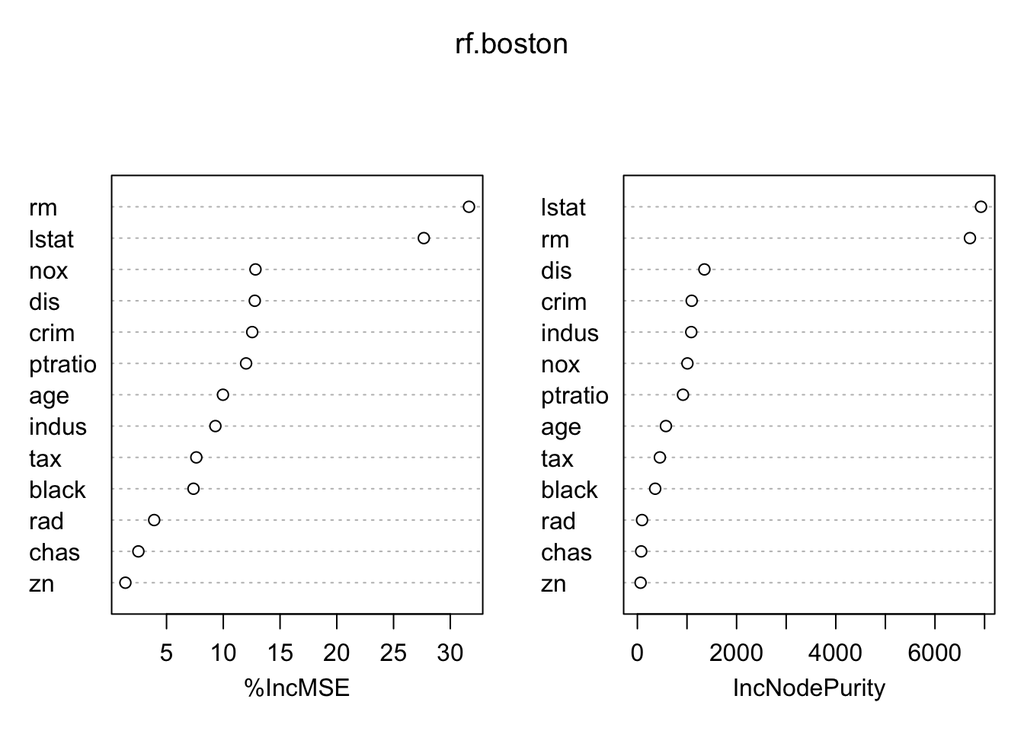

```r
varImpPlot(rf.boston)
```

The results indicate that across all of the trees considered in the random forest, the wealth level of the community (lstat) and the house size (rm) are by far the two most important variables.